### Trabalho de Programação

# Análise de dados de manchas solares

## Manchas solares

[figure not shown]

As manchas solares são a contagem de manchas na face visível do sol. Dados diários de sua contagem utilizando telescópios datam de 1610 e a partir de 1700 os dados são considerados consistentes para análise.

É possível perceber que as manchas estão relacionadas com o ciclo magnético do sol e são produzidas por um processo de dínamo hidromagnético. O modelo atual prevê dois dínamos acoplados.

Da mesma forma que em um dínamo eletromagnético temos uma espira rotacionando em um campo magnético temos um fluxo espiral de plasma (que também são bons condutores de calor) dentro do sol.

O sol apresenta atividade cíclica com duração média de 11 anos e amplitude variável. A importância dos dados de manchas solares fica evidente quanto utilizados para modelar e prever a amplitude do próximo ciclo solar: previsões atuais são variada e contraditórias, variando de intensidade baixa até moderada.

Previsões da intensidade da atividade solar são importantes para agricultura, telecomunicações e astronomia entre outros.

A intensidade da atividade solar está diretamente relacionada com a incidência de UVB na superfície, quantidade de Ozônio formada na atmosfera, formação de nuvens e interferência na comunicação por ondas curtas.

```python
import numpy as np
import pandas as pd
import matplotlib.pyplot as plt
from datetime import datetime

import seaborn as sns

from dateutil.relativedelta import relativedelta
from scipy.optimize import minimize

import statsmodels.formula.api as smf
import statsmodels.tsa.api as smt
import statsmodels.api as sm
import scipy.stats as scs

from itertools import product
from tqdm import tqdm_notebook

from sklearn.metrics import r2_score, median_absolute_error, mean_absolute_error
from sklearn.metrics import median_absolute_error, mean_squared_error, mean_squared_log_error
from statsmodels.graphics.api import qqplot

%matplotlib inline
```

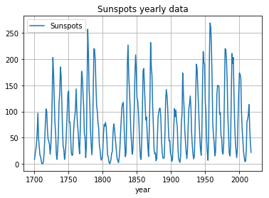

```python
dfy = pd.read_csv('SN_y_tot_V2.0.csv', sep=';', header=None)
dfy.columns = ['year','Sunspots','std','observations','verified']
dfy = dfy[['year','Sunspots']]
dfy.year = dfy.year-0.5
dfy_idx = dfy.set_index(['year'], drop=True)
data = dfy_idx[['Sunspots']]
data.plot(y='Sunspots')
plt.title('Sunspots yearly data')
plt.grid(True)

plt.show()
```

O trabalho foi desenvolvido para estudo e aprimoramento de técnicas de análise exploratória de dados partindo de uma proposta inicial que foi modificada:

### Proposta inicial:

Análise de dados de manchas solares no tempo e possível predição de ciclos futuros utilizando técnicas de Machine Learning.

Utilizar autoencoders de CNN para melhorar o modelo teórico estabelecido já que nenhum modelo até hoje foi capaz de prever dois ciclos seguidos satisfatóriamente.

### Dificuldades encontradas:

Dados e código do modelo teórico não disponíveis, análise teórica estatística, falta de familiaridade com a manipulação de séries temporais, dificuldade em encontrar códigos com abordagem prática devido às aplicações de séries temporais no mercado financeiro, necessidade de [feature design](http://www.cs.ucr.edu/~eamonn/meaningless.pdf) para a manipulação desse tipo de dado.

### Novo objetivo:

Análise exploratória dos dados de manchas solares, visualização, análise estatística e aplicação de métodos "clássicos": livro com abordagem prática para análise de séries temporais.

# Practical Time Series Analysis

### Master Time Series Data Processing, Visualization and Modeling using Python

Dr. Avishek Pal, Dr. PKS Prakash

*Notas*

livro de set/2017 - Atual

escrito por dois cientistas de dados

Modelos estatísticos + machine learning

## Capítulo 1: Introdução a Séries Temporais

### Diferentes tipos de dados

- Dados de corte transversal (cross-section)
- Série temporal
- Dados em painel (panel data)

*Notas*

dados de corte transversal: dados como o pib de uma lista de países no ano passado, dados descritivos da população brasileira, votação nas últimas eleições.

série temporal: dados de manchas solares, bolsa de valores, brl - usd

dados em painel: acompanhar os dados de corte transversal ao longo de um período de tempo, evolução dos indicadores de educação no brasil em um determinado período, gastos militares de usa, china, uk e india em % do pib.

Vamos analisar somente time series a fundo já aplicando qdo possível os dados de manchas solares

### Estruturas internas de séries temporais

- Tendência
- Sazonalidade (seasonality)
- Movimentos cíclicos
- Variações inesperadas

Baseado nesse modelo uma série temporal pode ser expressa por:

$$x_t = f_t+s_t+c_t+e_t$$

*notas*

Tendencia: pode ser em forma de reta, segunda ordem, exponencial

Sazonalidade: repetições periódicas em uma serie temporal. ao retirar a tendencia é possível observar

Movimentos cíclicos: ocorrem menos frequentemente que as flutuações sazonais, pode não ter um período fixo, assim como pra identificar tendencia, podem ser necessarios dados mto antigos.

Variações inesperadas: pode ser devido a falta de informação sobre variaveis que explicam esse fenomeno ou pela presença de random noise

*Notas*

O objetivo de uma série temporal é decompor nessas características acima e desenvolver modelos matemáticos pra cada uma. Esse modelo é utilizado para avaliar causas dos dados observados e predizer pontos futuros

```python
# Pré-tratamento dos dados
df = pd.read_csv('SN_m_tot_V2.0.csv', sep=';', header=None)
df.columns = ['year', 'month', 'FracDate', 'Sunspots', 'Std', 'Observations', 'Verified']
df = df[['year', 'month', 'Sunspots']]
df['Date'] = df.apply(lambda row: datetime(
                             int(row['year']), int(row['month']),1), axis=1)
df['Date'] = pd.to_datetime(df["Date"])
df_idx = df.set_index(["Date"], drop=True)
df_idx = df_idx.sort_index(axis=1, ascending=True)
```

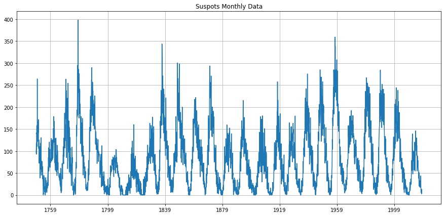

```python
#Plot manchas mensais
plt.figure(figsize=(15, 7))
plt.plot(df_idx.Sunspots)
plt.title('Suspots Monthly Data')
plt.grid(True)
plt.show()
```

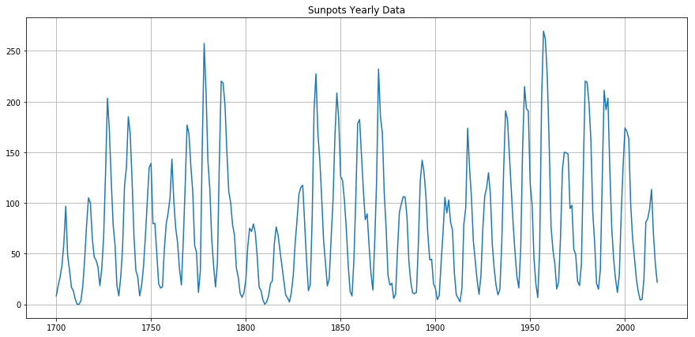

```python
plt.figure(figsize=(15, 7))
plt.plot(dfy_idx.Sunspots)
plt.title('Sunpots Yearly Data')
plt.grid(True)
plt.show()
```

### Modelos para análise de série temporal

- Modelos de média zero
- Random walk
- Modelos de tendência
- Modelos de sazonalidade

#### Modelos de média zero

Observações deste modelo são assumidas como sendo **independentes e identicamente distribuídas (iid)** e representam o random noise em torno da média fixa (subtraída da série temporal como termo constante).

#### Random walk

Dado como a soma de n iids. Pode ser reduzido ao modelo de média zero tomando as diferenças entre dois índices consecutivos:

$$ S_t-S_{t-1} = x_t$$

$x_t$ é iid com média zéro e variância constante.

#### Modelos de tendência

A escolha do modelo de tendência $\mu(t)$ é fundamental para a modelagem correta da série tempora. A análise exploratória dos dados normalmente dá dicas se devemos aplicar o modelo linear ou não linear em $t$.

$$\mu(t)=\omega t +b$$ $$\mu(t)=\omega_1 t+\omega_2 t^2 +b$$ $$\mu(t)=\omega_0 t^p +b$$

Exemplos de modelos lineares e não lineares de tendência.

#### Modelos de sazonalidade

Podem ser expressados pela soma ponderada de senos com peridiocidade conhecida:

$$s_t = \sum \frac{L}{k-1}(w_k\cos{\alpha t}+v_k\sin{\alpha t})+b$$

Também conhecido como modelo de regressão harmônica.

### Passo a passo para análise de uma série temporal

- Visualização de dados com diferentes granularidades de tempo para revelar tendência e flutuações sazonais.
- Identificação da tendência e plot do resíduo para identificar sazonalidade ou erro irredutível.
- Modelo de regressão harmônica para capturar a sazonalidade.
- Plotar o erro residual restante e identificar se é realmente erro irredutível.

### Autocorrelação e Autocorrelação parcial

Depois de aplicar as tranformações anteriores ficamos com o que é chamado de **série temporal estacionária**, caracterizada por uma média constante $E(x_t)$ e correlação dependente somente da diferença de tempo $h$ entre as duas observações e são independentes de seu valor $$E(x_t,x_{t+h})=g(h)$$

*Notas*

Quando normalizadas entre -1 e 1, chamamos essa relação de autocorrelação, isso garante que a série é independente do tempo e tem características que podem ser úteis na predição futura da série temporal.

correlação positiva sobe junto e negativa observáveis são inversamente proporcionais. Quanto mais próximo de zero menor a correlação e mais difícil de prever

*Notas*

Plot ACF com o intervalo de confiança de 95%. Autocorrelações fora do intervalo são estatisticamente relevante, dentro do intervalo são devidas ao ruído.

#### Autocorrelação Parcial

**Modelos autoregressivos (AR)** capturam a dependencia como regressão linear entre $x_{t+h}$ e $x_t$ mas da forma calculada anteriormente a influência dos valores intermediários $x_t, x_{t+1},...,x_{t+h-1}$ também são consideradas.

A autocorrelação parcial resolve esse problema definindo a correlação entre $x_{t+h}$ e $x_t$ desconsiderando os lags $t+1$ até $t+h-1$.

Ajuda na identificação da ordem $h$ de um modelo $AR(h)$.

*Notas*

- Plot_pacf, pontos acima do intervalo de confiança maiores que 1 (1 sempre está acima) nos dão a ordem: 1 ponto ordem 1, 2 pontos ordem 2...

## Capítulo 2: Entendendo os dados de uma série temporal

[figure not shown]

### Processos estacionários

Um **processo estacionário** requer que média, variância e autocorrelação sejam invariantes com respeito ao tempo da observação.

No entanto, a maioria dos processos reais em séries temporais não são estacionários. Uma etapa crucial na análise de séries temporais é verificar se uma série é estacionária e métodos para tornar processos não estácionários em estacionários, removendo tendência e sazonalidade.

### Teste de Dickey-Fuller aumentado

Teste com $H_0$ sendo um processo não estacionário e a hipótese alternativa um processo estácionário.

### Diferenciação

Podendo ser de primeira ordem ou de segunda ordem para eliminação da tendência:

$$\dot{x}_t = (x_t-x_{t-1})$$ $$\ddot{x}_t = (\dot{x}_t-\dot{x}_{t-1})= (x_t-x_{t-1})-(x_{t-1}-x_{t-2})$$

Se a série temporal tem sazonalidade com período conhecido $m$ a difereciação retira este efeito da série:

$$\dot{x}_t = x_t-x_{t-m} = \epsilon_t$$

### Médias móveis

**Médias móveis (MA)** estimam a tendência média calculada pela média no período de $t\pm k$ onde $k$ é o alcance da MA:

$$F_t=\frac{x_{t-k}+x_{t-k+1}+...+x_t+...+x_{t+k}}{2k+1}$$

Usualmente nos referimos ao número total de observações $m=2k+1$ como a MA de ordem $m$.

As médias móveis podem ser usadas para a suavização dos gráficos, foram descritas de forma simétrica a $x_t$ para o caso de $m$ ímpar mas podemos considerar ainda médias assimétricas $m=2k$.

```python
def mean_absolute_percentage_error(y_true, y_pred):
    return np.mean(np.abs((y_true - y_pred) / y_true)) * 100

def moving_average(series, n):
    """
        Calcula a média das ultimas n observaçoes
    """
    return np.average(series[-n:])

moving_average(df_idx, 12) # média anual
```

```
679.7027777777778
```

A assimetria de uma MA de ordem par pode ser eliminada tomando a segunda MA de ordem par. Como por exemplo no caso de $m=2$:

$$F_t^{(2)}=\frac{x_{t-1}+x_{t}}{2}$$

Aplicando uma segunda média móvel de segunda ordem à série $F_t^{(2)}$ produziremos uma média movel final simétrica:

$$2\times F_t^{(2)}=\frac{F_t^{(2)}+F_{t+1}^{(2)}}{2}=\frac{1}{2}\times \frac{x_{t-1}+x_t}{2}+\frac{x_{t}+x_{t+1}}{2}$$

$$=\frac{1}{4}x_{t-1}+\frac{1}{2}x_t+\frac{1}{4}x_{t+1}$$

Em geral, podemos criar as médias móveis $n\times F_t^{(m)}$ tomando primeiro a média de ordem $m$ seguida da média de ordem $n$. Para produzir uma MA simétrica $n$ e $m$ devem ser os dois pares ou os dois ímpares.

*Notas*

Uma característica importante é que podemos chamar de média móvel ponderada, quanto mais próximo de $x_t$ maior o peso dado à variável, o que gera um conjunto de dados com curva mais suave.

### Ajuste sazonal usando médias móveis

Podemos utilizar as séries $n\times F_t^{(m)}$ descritas anteriormente como médias ponderadas que podem ser aplicadas para suavizar dados com sazonalidade para gerar estimativas de tendência. Por exemplo para dados trimestrais podemos aplicar $2\times F_t^{(4)}$ (4 é o número de trimestres em um ano). A MA é tratada como a tendência dos dados e o resíduo avaliado pelo teste ACF.

```python
moving_average(dfy_idx, 11) #média por ciclo
```

```
79.19685534591194
```

### Decomposição de série temporal

#### Por médias móveis

Pela abordagem descrita temos que:

$$\epsilon_t=x_t-F_t-S_t$$ No modelo aditivo.

$$\epsilon_t=\frac{x_t}{F_t\times S_t}$$ No modelo multiplicativo.

```python
def plotMovingAverage(series, window, plot_intervals=False, scale=1.96, plot_anomalies=False):

    """
        series - dataframe with timeseries
        window - rolling window size
        plot_intervals - show confidence intervals
        plot_anomalies - show anomalies

    """
    rolling_mean = series.rolling(window=window).mean()

    plt.figure(figsize=(15,5))
    plt.title("Moving average\n window size = {}".format(window))
    plt.plot(rolling_mean, "g", label="Rolling mean trend")

    # Plot confidence intervals for smoothed values
    if plot_intervals:
        mae = sum(abs(series[window:]- rolling_mean[window:]))/len(series[window:])
        deviation = np.std(series[window:] - rolling_mean[window:])
        lower_bond = rolling_mean - (mae + scale * deviation)
        upper_bond = rolling_mean + (mae + scale * deviation)
        plt.plot(upper_bond, "r--", label="Upper Bond / Lower Bond")
        plt.plot(lower_bond, "r--")

        # Having the intervals, find abnormal values
        if plot_anomalies:
            anomalies = pd.DataFrame(index=series.index, columns=series.columns)
            anomalies[series<lower_bond] = series[series<lower_bond]
            anomalies[series>upper_bond] = series[series>upper_bond]
            plt.plot(anomalies, "ro", markersize=10)

    plt.plot(series[window:], label="Actual values")
    plt.legend(loc="upper left")
    plt.grid(True)
```

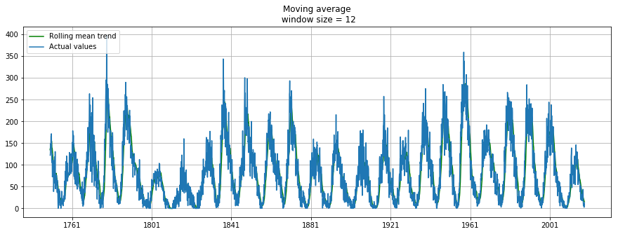

```python
plotMovingAverage(df_idx.Sunspots, 12)
```

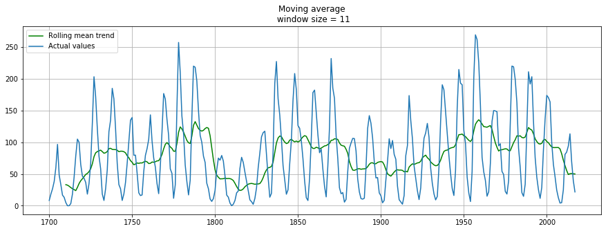

```python
plotMovingAverage(dfy_idx.Sunspots, 11)
```

```
Monthly Data
```

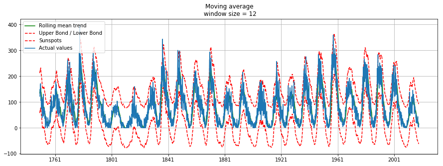

```python
print('Monthly Data')
plotMovingAverage(df_idx['Sunspots'], 12,plot_intervals=True)
```

## Capítulo 3: Métodos baseados em suavização exponencial

O processo de predição baseado na suavização exponencial pode ser resumido como filtros que tomam inputs e separam os componentes tendência e ruído como na figura:

[figure not shown]

### Suavização exponencial de primeira ordem

É aplicada em dados de variância constante e sem sazonalidade. Essa abordagem é recomendada para predições de curto prazo.

A fórmula geral é dada por: $$x_t=\alpha x_t+(1-\alpha)x_{t-1}$$

Aqui, o modelo é a média ponderada entre o valor atual e o valor anterior com um fator de suavização $\alpha$ que nos dá o quão rápido ''esqueceremos'' a última observação. Quanto menor o $\alpha$ maior é a influência dos valores anteriores e mais suave é a série.

A recursividade exponencial está na multiplicação a cada $t$ por $(1-\alpha)$.

A acurácia do modelo pode ser avaliada por funções como o **erro absoluto médio (MAS)** e o **erro quadrado médio (MSE)**

$$MSE =\frac{1}{N} \sum ^N_{i=1}(x_t-F_t)^2$$

$$MAS=\frac{1}{N} \sum ^N_{i=1}|x_t-F_t|$$

```python
def exponential_smoothing(series, alpha):
    """
        series - dataset with timestamps
        alpha - float [0.0, 1.0], smoothing parameter
    """
    result = [series[0]] # first value is same as series
    for n in range(1, len(series)):
        result.append(alpha * series[n] + (1 - alpha) * result[n-1])
    return result

def plotExponentialSmoothing(series, alphas):
    """
        Plots exponential smoothing with different alphas

        series - dataset with timestamps
        alphas - list of floats, smoothing parameters

    """
    with plt.style.context('seaborn-white'):
        plt.figure(figsize=(15, 7))
        for alpha in alphas:
            plt.plot(exponential_smoothing(series, alpha), label="Alpha {}".format(alpha))
        plt.plot(series.values, "c", label = "Actual")
        plt.legend(loc="best")
        plt.axis('tight')
        plt.title("Exponential Smoothing")
        plt.grid(True);
```

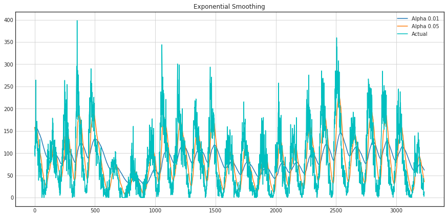

```python
plotExponentialSmoothing(df_idx.Sunspots, [0.01, 0.05])
```

### Suavização exponencial de segunda ordem

Aplicaremos a suavização anterior à tendência assumindo que a direção das mudanças da série temporal dependem da diferença dos pesos anteriores. Como resuldados tempos as seguintes funções com nível $\ell$ e tendência $b$:

$$\ell_t = \alpha x_t + (1-\alpha)(\ell_{t-1} + b_{t-1})$$

$$b_t = \beta(\ell_t - \ell_{t-1}) + (1-\beta)b_{t-1}$$

$$x_{t+1} = \ell_t + b_t$$

$\beta$ é o coeficiente de suavização da segunda exponencial. A predição é a soma do modelo de valores de $\ell$ e $b$.

Agora temos dois parâmetros $\alpha$ e $\beta$. O primeiro suaviza a curva em torno da tendência e o segundo suaviza a própria tendência.

```python
def double_exponential_smoothing(series, alpha, beta):
    """
        series - dataset with timeseries
        alpha - float [0.0, 1.0], smoothing parameter for level
        beta - float [0.0, 1.0], smoothing parameter for trend
    """
    # first value is same as series
    result = [series[0]]
    for n in range(1, len(series)+1):
        if n == 1:
            level, trend = series[0], series[1] - series[0]
        if n >= len(series): # forecasting
            value = result[-1]
        else:
            value = series[n]
        last_level, level = level, alpha*value + (1-alpha)*(level+trend)
        trend = beta*(level-last_level) + (1-beta)*trend
        result.append(level+trend)
    return result

def plotDoubleExponentialSmoothing(series, alphas, betas):
    """
        Plots double exponential smoothing with different alphas and betas

        series - dataset with timestamps
        alphas - list of floats, smoothing parameters for level
        betas - list of floats, smoothing parameters for trend
    """

    with plt.style.context('seaborn-white'):
        plt.figure(figsize=(20, 8))
        for alpha in alphas:
            for beta in betas:
                plt.plot(double_exponential_smoothing(series, alpha, beta), label="Alpha {}, beta {}".format(alpha, beta))
        plt.plot(series.values, label = "Actual")
        plt.legend(loc="best")
        plt.axis('tight')
        plt.title("Double Exponential Smoothing")
        plt.grid(True)
```

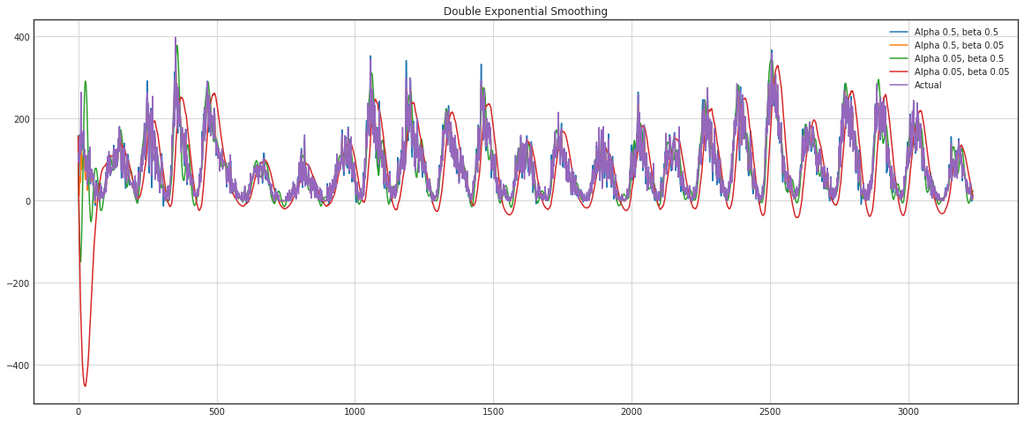

```python
plotDoubleExponentialSmoothing(df_idx.Sunspots, alphas=[0.5, 0.05], betas=[0.5, 0.05])
```

```python
class HoltWinters:

    """
    Holt-Winters model with the anomalies detection using Brutlag method

    # series - initial time series
    # slen - length of a season
    # alpha, beta, gamma - Holt-Winters model coefficients
    # n_preds - predictions horizon
    # scaling_factor - sets the width of the confidence interval by Brutlag (usually takes values from 2 to 3)

    """


    def __init__(self, series, slen, alpha, beta, gamma, n_preds, scaling_factor=1.96):
        self.series = series
        self.slen = slen
        self.alpha = alpha
        self.beta = beta
        self.gamma = gamma
        self.n_preds = n_preds
        self.scaling_factor = scaling_factor


    def initial_trend(self):
        sum = 0.0
        for i in range(self.slen):
            sum += float(self.series[i+self.slen] - self.series[i]) / self.slen
        return sum / self.slen

    def initial_seasonal_components(self):
        seasonals = {}
        season_averages = []
        n_seasons = int(len(self.series)/self.slen)

        for j in range(n_seasons):
            season_averages.append(sum(self.series[self.slen*j:self.slen*j+self.slen])/float(self.slen))

        for i in range(self.slen):
            sum_of_vals_over_avg = 0.0
            for j in range(n_seasons):
                sum_of_vals_over_avg += self.series[self.slen*j+i]-season_averages[j]
            seasonals[i] = sum_of_vals_over_avg/n_seasons
        return seasonals


    def triple_exponential_smoothing(self):
        self.result = []
        self.Smooth = []
        self.Season = []
        self.Trend = []
        self.PredictedDeviation = []
        self.UpperBond = []
        self.LowerBond = []

        seasonals = self.initial_seasonal_components()

        for i in range(len(self.series)+self.n_preds):
            if i == 0:
                smooth = self.series[0]
                trend = self.initial_trend()
                self.result.append(self.series[0])
                self.Smooth.append(smooth)
                self.Trend.append(trend)
                self.Season.append(seasonals[i%self.slen])

                self.PredictedDeviation.append(0)

                self.UpperBond.append(self.result[0] +
                                      self.scaling_factor *
                                      self.PredictedDeviation[0])

                self.LowerBond.append(self.result[0] -
                                      self.scaling_factor *
                                      self.PredictedDeviation[0])
                continue

            if i >= len(self.series): # predicting
                m = i - len(self.series) + 1
                self.result.append((smooth + m*trend) + seasonals[i%self.slen])

                # when predicting we increase uncertainty on each step
                self.PredictedDeviation.append(self.PredictedDeviation[-1]*1.01)

            else:
                val = self.series[i]
                last_smooth, smooth = smooth, self.alpha*(val-seasonals[i%self.slen]) + (1-self.alpha)*(smooth+trend)
                trend = self.beta * (smooth-last_smooth) + (1-self.beta)*trend
                seasonals[i%self.slen] = self.gamma*(val-smooth) + (1-self.gamma)*seasonals[i%self.slen]
                self.result.append(smooth+trend+seasonals[i%self.slen])

                # Deviation is calculated according to Brutlag algorithm.
                self.PredictedDeviation.append(self.gamma * np.abs(self.series[i] - self.result[i])
                                               + (1-self.gamma)*self.PredictedDeviation[-1])

            self.UpperBond.append(self.result[-1] +
                                  self.scaling_factor *
                                  self.PredictedDeviation[-1])

            self.LowerBond.append(self.result[-1] -
                                  self.scaling_factor *
                                  self.PredictedDeviation[-1])

            self.Smooth.append(smooth)
            self.Trend.append(trend)
            self.Season.append(seasonals[i%self.slen])
```

```python
from sklearn.model_selection import TimeSeriesSplit

def timeseriesCVscore(params, series, loss_function=mean_squared_error, slen=132):
    """
        Returns error on CV

        params - vector of parameters for optimization
        series - dataset with timeseries
        slen - season length for Holt-Winters model
    """
    # errors array
    errors = []

    values = series.values
    alpha, beta, gamma = params

    # set the number of folds for cross-validation
    tscv = TimeSeriesSplit(n_splits=3)

    # iterating over folds, train model on each, forecast and calculate error
    for train, test in tscv.split(values):

        model = HoltWinters(series=values[train], slen=slen,
                            alpha=alpha, beta=beta, gamma=gamma, n_preds=len(test))
        model.triple_exponential_smoothing()

        predictions = model.result[-len(test):]
        actual = values[test]
        error = loss_function(predictions, actual)
        errors.append(error)

    return np.mean(np.array(errors))
```

```python
%%time
#data = df_idx.Sunspots[:-20] # leave some data for testing
from sklearn.preprocessing import MinMaxScaler
sc = MinMaxScaler()
data = df_idx[['Sunspots']]
split_date = pd.Timestamp('01-01-1964')

train = data.loc[:split_date]
test = data.loc[split_date:]
```

```
CPU times: user 5.48 ms, sys: 186 µs, total: 5.67 ms
Wall time: 4.94 ms
```

```python
# initializing model parameters alpha, beta and gamma
x = [0, 0, 0]
# train_sc_df = pd.DataFrame(train_sc, columns=['Y'], index=train.index)
# test_sc_df = pd.DataFrame(test_sc, columns=['Y'], index=test.index)
data = df_idx.Sunspots[:-132]
# Minimizing the loss function
opt = minimize(timeseriesCVscore, x0=x,
               args=(data, mean_squared_error),
               method="TNC", bounds = ((0, 1), (0, 1), (0, 1))
              )

# Take optimal values...
alpha_final, beta_final, gamma_final = opt.x
print(alpha_final, beta_final, gamma_final)

# ...and train the model with them, forecasting for the next 50 hours
model = HoltWinters(data, slen = 132,
                    alpha = alpha_final,
                    beta = beta_final,
                    gamma = gamma_final,
                    n_preds = 264, scaling_factor = 3)
model.triple_exponential_smoothing()
```

```
0.001544256319870596 0.00452645841153182 0.033199541840496116
```

```python
def plotHoltWinters(series, plot_intervals=False, plot_anomalies=False):
    """
        series - dataset with timeseries
        plot_intervals - show confidence intervals
        plot_anomalies - show anomalies
    """

    plt.figure(figsize=(20, 10))
    plt.plot(model.result, label = "Model")
    plt.plot(series.values, label = "Actual")
    error = np.sqrt(np.sum((series.values-model.result[:len(series)])*(series.values-model.result[:len(series)]))/len(series))
    plt.title("Mean Absolute Percentage Error: {0:.2f}%".format(error))

    if plot_anomalies:
        anomalies = np.array([np.NaN]*len(series))
        anomalies[series.values<model.LowerBond[:len(series)]] = \
            series.values[series.values<model.LowerBond[:len(series)]]
        anomalies[series.values>model.UpperBond[:len(series)]] = \
            series.values[series.values>model.UpperBond[:len(series)]]
        plt.plot(anomalies, "o", markersize=10, label = "Anomalies")

    if plot_intervals:
        plt.plot(model.UpperBond, "r--", alpha=0.5, label = "Up/Low confidence")
        plt.plot(model.LowerBond, "r--", alpha=0.5)
        plt.fill_between(x=range(0,len(model.result)), y1=model.UpperBond,
                         y2=model.LowerBond, alpha=0.2, color = "grey")

    plt.vlines(len(series), ymin=-50, ymax=+400, linestyles='dashed')
    plt.axvspan(len(series)-132, len(model.result), alpha=0.3, color='lightgrey')
    plt.grid(True)
    plt.axis('tight')
    plt.legend(loc="best", fontsize=13);
```

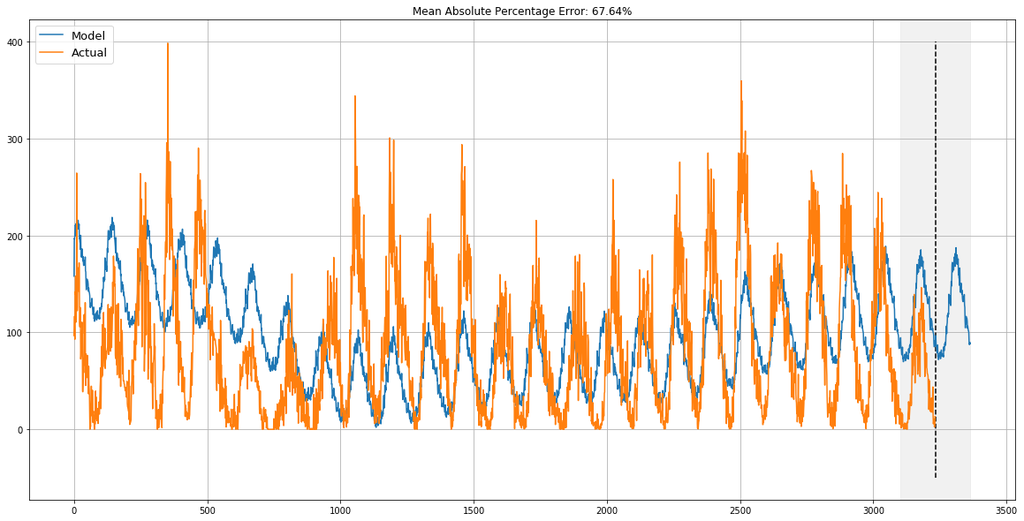

```python
plotHoltWinters(df_idx.Sunspots)
```

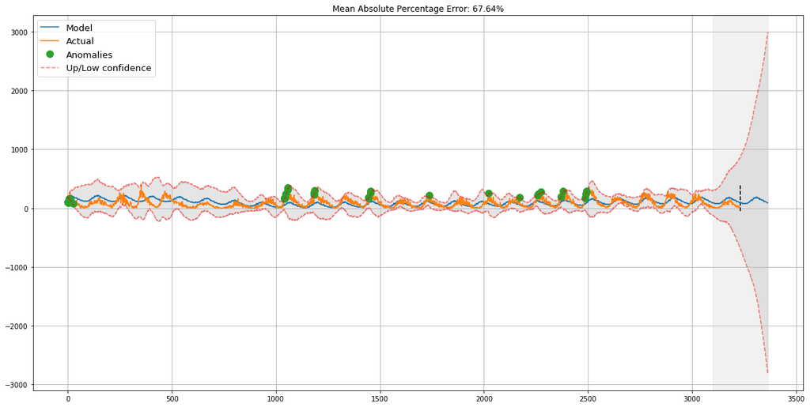

```python
plotHoltWinters(df_idx.Sunspots,plot_intervals=True,plot_anomalies=True)
```

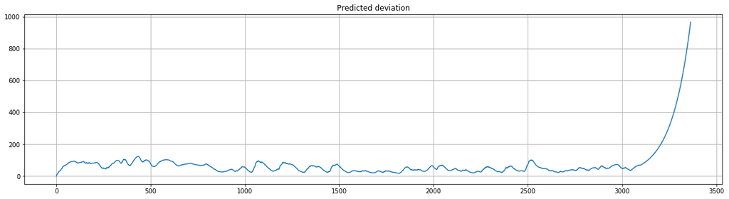

```python
plt.figure(figsize=(20, 5))
plt.plot(model.PredictedDeviation)
plt.grid(True)
plt.axis('tight')
plt.title("Predicted deviation")
plt.show()
```

## Capítulo 4: Modelos Autorregressivos

### Modelos autorregressivos

**Modelos autorregressivos (AR)** são modelos estatísticos muitos bons em predição de séries temporais em que os valores seguintes dependem dos valores anteriores. Assim, modelos AR são muito utilizados na predição de séries temporais.

Os modelos autorregressivos são definidos como AR$(p)$ onde $p$ é a ordem do comporente AR.

O modelo AR de primeira ordem, AR(1): $$x_t=\phi x_{t-1}+\in_t$$

AR(2):

$$x_t=\phi_1 x_{t-1}+\phi_2 x_{t-2}+\in_t$$

O modelo AR de p-ésima ordem, AR$(p)$: $$x_t=\phi_1 x_{t-1}+\phi_2 x_{t-2}+...+\phi_p x_{t-p}+\in_t$$

$\phi$ é o coeficiente do modelo, $\in_t\approx N(0,\sigma^2)$ é o erro no tempo $t$.

### Modelos de Médias Móveis:

Similarmente ao modelo AR o **modelo de médias móvias (MA)** tem o mesmo objetivo e ordem $q$, porém nestes modelos a suposição é que o erro atual depende do erro anterior.

### Modelo ARMA

A combinação dos modelos anteriores AR$(p)$ e MA$(q)$ forma o modelo ARMA$(p,q)$:

$$ x_t = \alpha + \phi_1 x_{t-1} + \phi_2 x_{t-2} +...+ \phi_p x_{p-q}-\theta_1\epsilon_{t-1}-\theta_2\epsilon_{t-2}-...-\theta_q\epsilon_{t-q}+\epsilon_t $$

- Autocorrelação decrescente exponencialmente e PACF com correlação significativa usando lag 1, então usamos o parâmetro $p$
- Autocorrelação formando um padrão seno e PACF com correlação significativa com lags 1 e 2, usamos $p=2$
- Autocorrelação é significativa e PACF cai exponencialmente, usar parâmetro $q$
- Autocorrelação é significativa e PACF tem padrão seno, usar parâmetro $q$

```python
def tsplot(y, lags=None, figsize=(12, 7), style='bmh'):
    """
        Plot time series, its ACF and PACF, calculate Dickey–Fuller test

        y - timeseries
        lags - how many lags to include in ACF, PACF calculation
    """
    if not isinstance(y, pd.Series):
        y = pd.Series(y)

    with plt.style.context(style):
        fig = plt.figure(figsize=figsize)
        layout = (2, 2)
        ts_ax = plt.subplot2grid(layout, (0, 0), colspan=2)
        acf_ax = plt.subplot2grid(layout, (1, 0))
        pacf_ax = plt.subplot2grid(layout, (1, 1))

        y.plot(ax=ts_ax)
        p_value = sm.tsa.stattools.adfuller(y)[1]
        ts_ax.set_title('Time Series Analysis Plots\n Dickey-Fuller: p={0:.5f}'.format(p_value))
        smt.graphics.plot_acf(y, lags=lags, ax=acf_ax)
        smt.graphics.plot_pacf(y, lags=lags, ax=pacf_ax)
        plt.tight_layout()
```

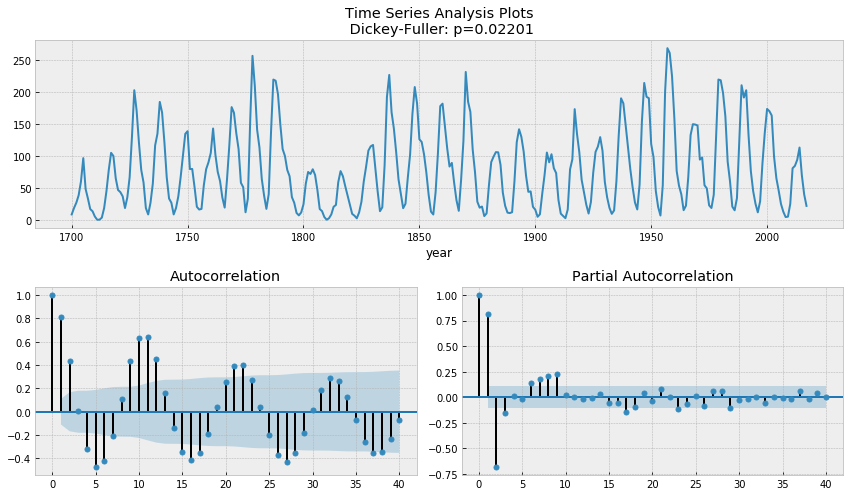

```python
tsplot(dfy_idx.Sunspots, lags=40)
```

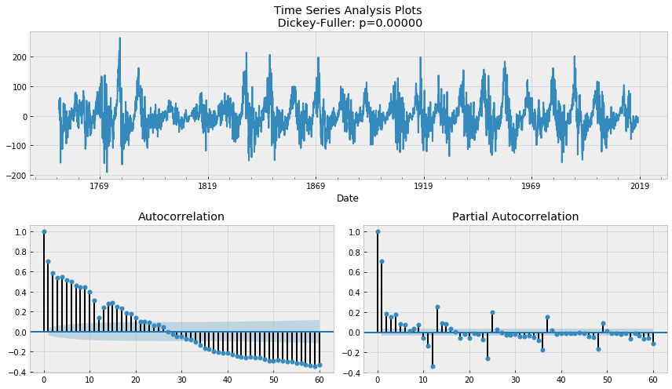

```python
ads_diff = df_idx.Sunspots - df_idx.Sunspots.shift(12)
tsplot(ads_diff[12:], lags=60)
```

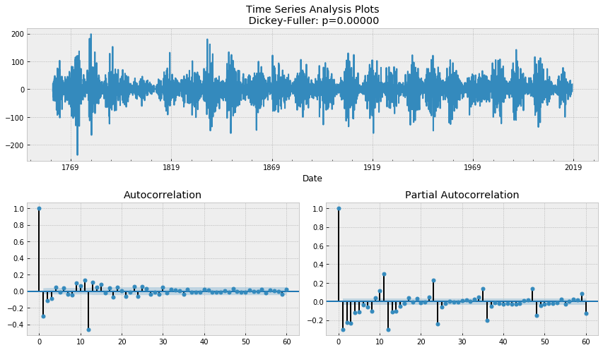

```python
ads_diff = ads_diff - ads_diff.shift(1)
tsplot(ads_diff[132+1:], lags=60)
```

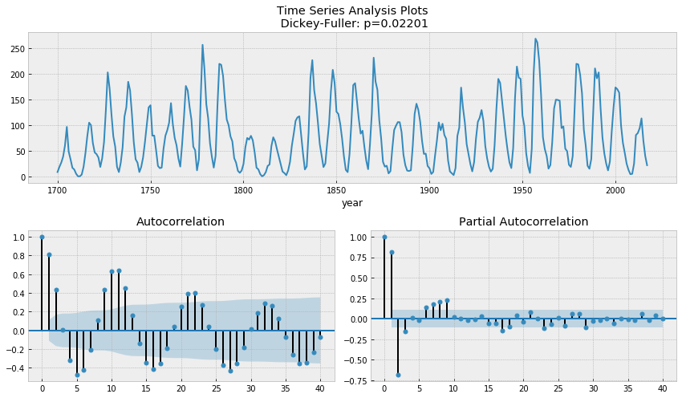

```python
tsplot(dfy_idx.Sunspots, lags=40)
```

```python
df = pd.read_csv('SN_y_tot_V2.0.csv', sep=';', header=None)
df.columns = ['year', 'Sunspots', 'Std', 'Observations', 'Verified']

df['Date'] = df.apply(lambda row: datetime(
                              int(row['year']), 12,31), axis=1)
df['Date'] = pd.to_datetime(df["Date"])
dfy_idx = df.set_index(["Date"], drop=True)
# dfy_idx.head()
```

```python
arma_mod20 = sm.tsa.statespace.SARIMAX(dfy_idx.Sunspots, order=(2,0,0), trend='c').fit(disp=False)
# print(arma_mod20.params)
# print(arma_mod20.aic, arma_mod20.bic, arma_mod20.hqic)
```

```python
arma_mod30 = sm.tsa.statespace.SARIMAX(dfy_idx.Sunspots, order=(3,0,0), trend='c').fit(disp=False)
# print(arma_mod30.params)
# print(arma_mod30.aic, arma_mod30.bic, arma_mod30.hqic)
```

```python
resid = arma_mod30.resid
sm.stats.durbin_watson(arma_mod30.resid)
```

```
1.9682693644563445
```

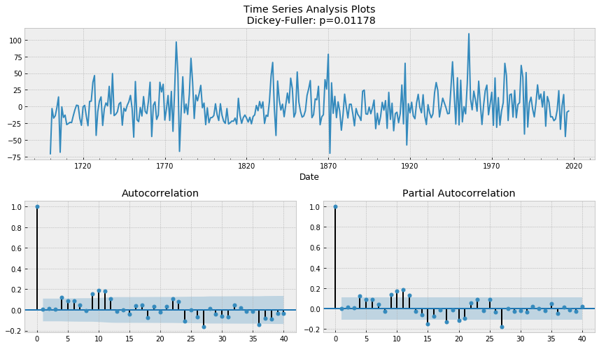

```python
#ARMA(3,0,0)
tsplot(resid, lags=40)
```

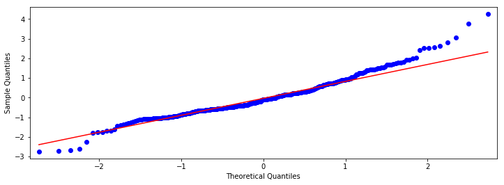

```python
#qq plot para verificar normalidade da distribuição
fig = plt.figure(figsize=(12,4))
ax = fig.add_subplot(111)
fig = qqplot(resid, line='q', ax=ax, fit=True)
```

```python
predict_sunspots = arma_mod30.predict(start='1700', end='2030', dynamic=False)
```

```python
arma_mod302 = sm.tsa.statespace.SARIMAX(dfy_idx.Sunspots, order=(3,0,2),trend='c').fit(disp=True)
predict_sunspots = arma_mod302.predict(start='1700', end='2030', dynamic=False)
```

[figure not shown]

```python
fig, ax = plt.subplots(figsize=(12, 8))
dfy_idx.Sunspots.plot(ax=ax)
predict_sunspots.plot(ax=ax, style='--r')
plt.title('ARMA(3,0,0) Model prediction')
plt.show()
```

```python
def mean_forecast_err(y, yhat):
    return y.sub(yhat).mean()
```

```python
mean_forecast_err(dfy_idx.Sunspots, predict_sunspots)
```

```
-0.10449296346399331
```

### Modelo ARIMA

É uma generalização do modelo ARMA que inclui componentes integradas.

Uma extensão importante do modelo ARIMA é a inclusão da sazonalidade no modelo. Ele possui então seis parâmetros ARIMA$(p,d,q)(P,D,Q)_m$ onde P, D e Q representam a parte sazonal do modelo autorregressivo. O $m$ é o número de períodos na série.

## Capítulo 5: Deep Learning para predição de série temporal

A ideia de predição linear pode ser generalizada em seu objetivo principal: desenvolver uma função $f$ que prediz $x_t$ a partir de observações em tempos $p$ anteriores:

$$x_t=f(x_{t-1},x_{t-2},...,x_{t-p})$$

Os métodos apresentados neste capítulo encontam o $f$ a partir da definição de redes neurais (podem variar o número de *hidden layers*, o número de neurons) e do seu treinamento (usando *backpropagation* ou alguma variante apropriada para a aquitetura da rede neural usada).

*Notas*

Chamamos de **deep learning** uma gama de métodos de aprendizado de máquinas mas o mais conhecido são as redes neurais com muitas *hidden layers*.

A arquitetura da rede neural deve ser adequada aos dados de entrada e saída, por exemplo: **redes neurais convolucionais (CNN)** são mais apropriadas para dados estruturados em 2D ou 3D (muito utilizada na classificação de imagens) enquanto **redes neurais recorrentes (RNN)** são utilizadas para modelos de análise de linguagem.

A análise de séries temporais tem se mostrado promissora.

### O que são as redes neurais

[figure not shown]

### A estrutura dos neurons

[figure not shown]

```python
df = pd.read_csv('SN_d_tot_V2.0.csv', sep=';', header=None)
df.columns = ['year', 'month','day', 'FracDate', 'Sunspots', 'Std', 'Observations', 'Verified']
df = df[['year','month','day', 'Sunspots']]
df['Date'] = df.apply(lambda row: datetime(
                              int(row['year']), int(row['month']),int(row['day'])), axis=1)

df['Date'] = pd.to_datetime(df["Date"])
df_idx = df.set_index(["Date"], drop=True)

daily_sun= df[['Date','Sunspots']]#df.head()
daily_sun = daily_sun.set_index(["Date"], drop=True)
# daily_sun.head()
```

```python
daily_sun = daily_sun.sort_index(axis=1, ascending=True)
# daily_sun = daily_sun.iloc[::-1]
# daily_sun.head(10)
```

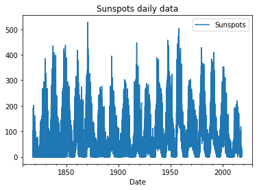

```python
data = daily_sun[['Sunspots']]
data.plot(y='Sunspots')
plt.title('Sunspots daily data')
plt.show()
```

```python
data.head()
```

| Date | Sunspots |
| --- | --- |
| 1818-01-01 | -1 |
| 1818-01-02 | -1 |
| 1818-01-03 | -1 |
| 1818-01-04 | -1 |
| 1818-01-05 | -1 |

```python
diff = data.index.values[-1] - data.index.values[0]
days = diff.astype('timedelta64[D]')
days = days / np.timedelta64(1, 'D')
years = int(days/365)
print("Total data: %d years"%years)
print("80 percent data = 1749 to %d"%(1818 + int(0.8*years)))
```

[output not shown]

```python
split_date = pd.Timestamp('01-01-1978')

train = data.loc[:split_date]
test = data.loc[split_date:]
```

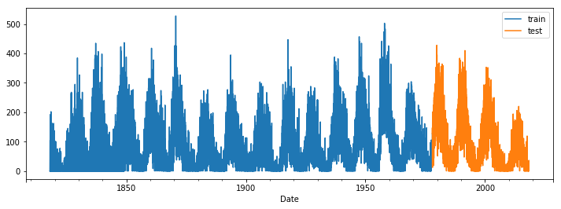

```python
ax = train.plot(figsize=(12,4))
test.plot(ax=ax)
plt.legend(['train', 'test'])
plt.show()
```

```python
from sklearn.preprocessing import MinMaxScaler
sc = MinMaxScaler()
train_sc = sc.fit_transform(train)
test_sc = sc.transform(test)
```

```python
train_sc_df = pd.DataFrame(train_sc, columns=['Y'], index=train.index)
test_sc_df = pd.DataFrame(test_sc, columns=['Y'], index=test.index)
```

```python
for s in range(1,2):
    train_sc_df['X_{}'.format(3960)] = train_sc_df['Y'].shift(3960)
    test_sc_df['X_{}'.format(3960)] = test_sc_df['Y'].shift(3960)
    print(s)
```

```
1
```

```python
s=3960
train_a = train_sc_df['Y'].shift(s)
test_a = test_sc_df['Y'].shift(s)
```

```python
X_train = train_sc_df.dropna().drop('Y', axis=1)
y_train = train_sc_df.dropna().drop('X_'+str(s), axis=1)

X_test = test_sc_df.dropna().drop('Y', axis=1)
y_test = test_sc_df.dropna().drop('X_'+str(s), axis=1)

X_train = X_train.as_matrix()
y_train = y_train.as_matrix()

X_test = X_test.as_matrix()
y_test = y_test.as_matrix()
```

```python
X_train = train_a.dropna()
y_train = train_sc_df.dropna()

X_test = test_a.dropna()
y_test = test_sc_df.dropna()

X_train = np.vstack(X_train.as_matrix())
y_train = np.vstack(y_train.as_matrix())

X_test = np.vstack(X_test.as_matrix())
y_test = np.vstack(y_test.as_matrix())
```

```python
y_train
```

```
array([[0.19092628],
       [0.19659735],
       [0.18714556],
       ...,
       [0.17391304],
       [0.18147448],
       [0.24196597]])
```

```python
print('Train size:',(X_train.shape),y_train.shape)
print('Test size: ',X_test.shape)
```

```
Train size: (54480, 1) (54480, 1)
Test size:  (10801, 1)
```

### Modelo SVM regressivo

```python
from sklearn.svm import SVR
regressor = SVR(kernel='rbf')
```

```python
regressor.fit(X_train, y_train)
y_pred = regressor.predict(X_test)
```

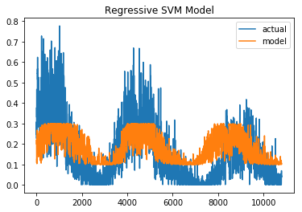

```python
plt.plot(y_test)
plt.plot(y_pred)
plt.legend(['actual', 'model'])
plt.title('Regressive SVM Model')
plt.show()
```

```python
from sklearn.metrics import r2_score

def adj_r2_score(r2, n, k):
    return 1-((1-r2)*((n-1)/(n-k-1)))

r2_test = r2_score(y_test, y_pred)
print("R-squared is: %f"%r2_test)
```

```
R-squared is: 0.318448
```

## Usando Redes Neurais

```python
import keras
from keras.models import Sequential
from keras.layers import Dense
from keras.optimizers import Adam
import keras.backend as K
```

### 1 hidden layer com 1 neuron

```python
K.clear_session()
model = Sequential()
model.add(Dense(1, input_shape=(X_test.shape[1],), activation='tanh', kernel_initializer='lecun_uniform'))
model.compile(optimizer=Adam(lr=0.0001), loss='mean_squared_error')
model.fit(X_train, y_train, batch_size=1, epochs=6, verbose=1)
```

```
<keras.callbacks.History at 0x7f3fc1f894a8>
```

```
R-Squared: 0.327430
```

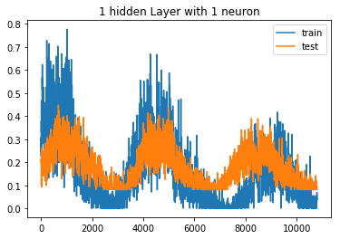

```python
y_pred = model.predict(X_test)
y_pred2 = model.predict(X_train)
plt.plot(y_test)
plt.plot(y_pred)
# plt.plot(X_train)
# plt.plot(y_pred2)
plt.legend(['train', 'test'])
plt.title('1 hidden Layer with 1 neuron')
print('R-Squared: %f'%(r2_score(y_test, y_pred)))
```

```
Text(0.5,1,'Last predicted data')
```

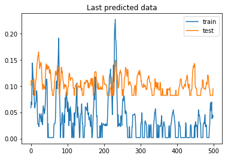

```python
plt.plot(y_test[len(y_test)-500:])
plt.plot(y_pred[len(y_pred)-500:])
plt.legend(['train', 'test'])
plt.title('Last predicted data')
```

### ANN

```python
from keras.models import Sequential
from keras.layers import Dense
import keras.backend as K
from keras.callbacks import EarlyStopping
from keras.optimizers import Adam
from keras.models import load_model
```

```python
sc = MinMaxScaler()
train_sc = sc.fit_transform(train)
test_sc = sc.transform(test)
```

```python
X_train = train_sc[:-s]
y_train = train_sc[s:]

X_test = test_sc[:-s]
y_test = test_sc[s:]
```

```python
K.clear_session()

model = Sequential()
model.add(Dense(12, input_dim=1, activation='relu'))
model.add(Dense(1))
model.compile(loss='mean_squared_error', optimizer='adam')
early_stop = EarlyStopping(monitor='loss', patience=2, verbose=1)
history = model.fit(X_train, y_train, epochs=4, batch_size=1, verbose=1, callbacks=[early_stop], shuffle=False)
```

```python
model.save('ANN_NonShift.h5')
```

```python
y_pred_test_ann = model.predict(X_test)
y_train_pred_ann = model.predict(X_train)
print("R2 score on the Train set:\t{:0.3f}".format(r2_score(y_train, y_train_pred_ann)))
r2_train = r2_score(y_train, y_train_pred_ann)
print("Adjusted R2 score on the Train set:\t{:0.3f}\n".format(adj_r2_score(r2_train, X_train.shape[0], X_train.shape[1])))
print("R2 score on the Test set:\t{:0.3f}".format(r2_score(y_test, y_pred_test_ann)))
r2_test = r2_score(y_test, y_pred_test_ann)
print("Adjusted R2 score on the Test set:\t{:0.3f}".format(adj_r2_score(r2_test, X_test.shape[0], X_test.shape[1])))
```

[output not shown]

[output cut: 17 more lines]

[output not shown]

## LSTM

```python
X_tr_t = X_train.reshape(X_train.shape[0], 1, X_train.shape[1])
X_tst_t = X_test.reshape(X_test.shape[0], 1, X_test.shape[1])
```

```python
from keras.layers import LSTM
K.clear_session()
model_lstm = Sequential()
model_lstm.add(LSTM(7, input_shape=(1, X_train.shape[1]), activation='relu', kernel_initializer='lecun_uniform', return_sequences=False))
model_lstm.add(Dense(1))
model_lstm.compile(loss='mean_squared_error', optimizer='adam')
early_stop = EarlyStopping(monitor='loss', patience=5, verbose=1)
history_model_lstm = model_lstm.fit(X_tr_t, y_train, epochs=4, batch_size=1, verbose=1, shuffle=False, callbacks=[early_stop])
```

```python
y_pred_test_lstm = model_lstm.predict(X_tst_t)
y_train_pred_lstm = model_lstm.predict(X_tr_t)
print("The R2 score on the Train set is:\t{:0.3f}".format(r2_score(y_train, y_train_pred_lstm)))
r2_train = r2_score(y_train, y_train_pred_lstm)
print("The Adjusted R2 score on the Train set is:\t{:0.3f}\n".format(adj_r2_score(r2_train, X_train.shape[0], X_train.shape[1])))
print("The R2 score on the Test set is:\t{:0.3f}".format(r2_score(y_test, y_pred_test_lstm)))
r2_test = r2_score(y_test, y_pred_test_lstm)
print("The Adjusted R2 score on the Test set is:\t{:0.3f}".format(adj_r2_score(r2_test, X_test.shape[0], X_test.shape[1])))
```

```
The R2 score on the Train set is:	-0.119
The Adjusted R2 score on the Train set is:	-0.119

The R2 score on the Test set is:	-0.166
The Adjusted R2 score on the Test set is:	-0.166
```

```python
model_lstm.save('LSTM_NonShift.h5')
```

### Avaliação dos modelos

```python
model_ann = load_model('ANN_NonShift.h5')
model_lstm = load_model('LSTM_NonShift.h5')
```

```python
score_ann= model_ann.evaluate(X_test, y_test, batch_size=1)
score_lstm= model_lstm.evaluate(X_tst_t, y_test, batch_size=1)
```

```python
print('ANN: %f'%score_ann)
print('LSTM: %f'%score_lstm)
```

```
ANN: 0.023382
LSTM: 0.023316
```

```python
y_pred_test_ANN = model_ann.predict(X_test)
y_pred_test_LSTM = model_lstm.predict(X_tst_t)
```

```python
col1 = pd.DataFrame(y_test, columns=['True'])
col2 = pd.DataFrame(y_pred_test_ANN, columns=['ANN_prediction'])
col3 = pd.DataFrame(y_pred_test_LSTM, columns=['LSTM_prediction'])
col4 = pd.DataFrame(history.history['loss'], columns=['Loss_ANN'])
col5 = pd.DataFrame(history_model_lstm.history['loss'], columns=['Loss_LSTM'])
results = pd.concat([col1, col2, col3, col4, col5], axis=1)
#results.to_excel('PredictionResults_ANN-LSTM_NonShift.xlsx')
```

```python
y_pred2 = model_ann.predict(X_train)
```

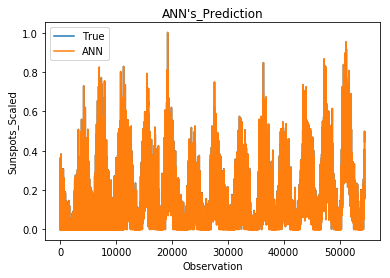

```python
y_pred_test_ANN = y_pred_test_ANN*-1*100+10.44
# plt.plot(y_test, label='True')
# plt.plot(y_pred_test_ANN, label='ANN')
plt.plot(X_train, label='True')
plt.plot(y_pred2*-1*200+20.87, label='ANN')

plt.title("ANN's_Prediction")
plt.xlabel('Observation')
plt.ylabel('Sunspots_Scaled')
plt.legend()
plt.show()
```

```python
y_pred3 = model_ann.predict(X_test)
X_test
```

```
array([[0.24196597],
       [0.25330813],
       [0.27977316],
       ...,
       [0.00189036],
       [0.00189036],
       [0.02835539]])
```

[output not shown]

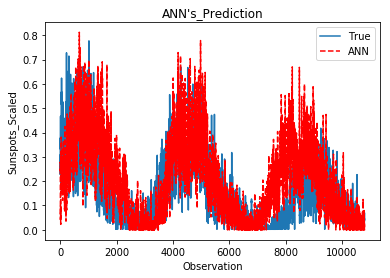

```python
y_pred_test_ANN = y_pred_test_ANN*-1*200+20.87
plt.plot(y_test, label='True')
plt.plot(y_pred3*-1*200+20.87, '--r',label='ANN')
#lt.plot(X_train, label='True')
#plt.plot(y_pred2*-1*200+20.87, label='ANN')

plt.title("ANN's_Prediction")
plt.xlabel('Observation')
plt.ylabel('Sunspots_Scaled')
plt.legend()
plt.show()
```

```python
r2_test = r2_score(y_test, y_pred_test_ANN)
print("Adjusted R2 score on the Test set:\t{:0.3f}".format(adj_r2_score(r2_test, X_test.shape[0], X_test.shape[1])))
```

```
Adjusted R2 score on the Test set:	0.203
```

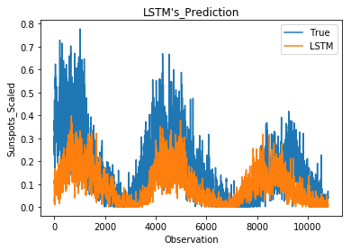

```python
plt.plot(y_test, label='True')
plt.plot(y_pred_test_LSTM*-1*(200)+20.74, label='LSTM')
plt.title("LSTM's_Prediction")
plt.xlabel('Observation')
plt.ylabel('Sunspots_Scaled')
plt.legend()
plt.show()
```

## Conclusões

Não foi possível prever dados do próximo ciclo com as abordagem utilizadas mas o conhecimento de manipulação de séries temporais com métodos estatísticos podem ser aplicados a uma infinidade de outros dados disponíveis.

Uma abordagem diferente pode ser utilizar o modelo ARMA e o resíduo como entrada da rede.

## Referências

Practical Time Series Analysis: Master Time Series Data Processing, Visualization, and Modeling using Python - Dr. Avishek Pal, Dr. PKS Prakash

An Elementary Introduction to Solar Dynamo Theory: Arnab Rai Choudhuri - http://www.physics.iisc.ernet.in/~arnab/lectures.pdf

https://medium.com/open-machine-learning-course/open-machine-learning-course-topic-9-time-series-analysis-in-python-a270cb05e0b3

https://www.youtube.com/watch?v=aircAruvnKk

http://www.blackarbs.com/blog/time-series-analysis-in-python-linear-models-to-garch/11/1/2016

http://www.cs.ubc.ca/~nando/540-2013/lectures.html

https://en.wikipedia.org/wiki/Long_short-term_memory